# IODS course project

## Creating a regression model

For closer inspection variables “age”, “attitude” and “surf” were selected to explain the target variable “points”

```r
my_model <- lm(points ~ age + attitude + surf, data = lrn2014)
summary(my_model)
```

```
##
## Call:
## lm(formula = points ~ age + attitude + surf, data = lrn2014)
##
## Residuals:
##     Min      1Q  Median      3Q     Max
## -17.973  -3.430   0.167   3.997  10.444
##
## Coefficients:
##             Estimate Std. Error t value Pr(>|t|)
## (Intercept) 16.85628    3.53786   4.765 4.18e-06 ***
## age         -0.08713    0.05361  -1.625    0.106
## attitude     3.42388    0.57353   5.970 1.45e-08 ***
## surf        -0.96049    0.79943  -1.201    0.231
## ---
## Signif. codes:  0 '***' 0.001 '**' 0.01 '*' 0.05 '.' 0.1 ' ' 1
##
## Residual standard error: 5.294 on 162 degrees of freedom
## Multiple R-squared:  0.2082, Adjusted R-squared:  0.1935
## F-statistic:  14.2 on 3 and 162 DF,  p-value: 2.921e-08
```

Alpha is appr. 16,86 points, and the greatest effect to the exam points has attitude, 3,42 points. Age does not predict points very well as the effect is negative, -0,09 points, and answers to surface level questions have slightly negative effect on exam points, -0.96. The p-value of attitude in relation to points is statistically significant, which can be interpreted to confirm that attitude actually impacts exam points. To find a better fitting model, both age and surf were at a time removed from the model.

```r
my_model2 <- lm(points ~ attitude + surf, data = lrn2014)
summary(my_model2)
```

```
##
## Call:
## lm(formula = points ~ attitude + surf, data = lrn2014)
##
## Residuals:
##     Min      1Q  Median      3Q     Max
## -17.277  -3.236   0.386   3.977  10.642
##
## Coefficients:
##             Estimate Std. Error t value Pr(>|t|)
## (Intercept)  14.1196     3.1271   4.515 1.21e-05 ***
## attitude      3.4264     0.5764   5.944 1.63e-08 ***
## surf         -0.7790     0.7956  -0.979    0.329
## ---
## Signif. codes:  0 '***' 0.001 '**' 0.01 '*' 0.05 '.' 0.1 ' ' 1
##
## Residual standard error: 5.32 on 163 degrees of freedom
## Multiple R-squared:  0.1953, Adjusted R-squared:  0.1854
## F-statistic: 19.78 on 2 and 163 DF,  p-value: 2.041e-08
```

```r
my_model3 <- lm(points ~ age + attitude, data = lrn2014)
summary(my_model3)
```

```
##
## Call:
## lm(formula = points ~ age + attitude, data = lrn2014)
##
## Residuals:
##      Min       1Q   Median       3Q      Max
## -17.3354  -3.3095   0.2625   4.0005  10.4911
##
## Coefficients:
##             Estimate Std. Error t value Pr(>|t|)
## (Intercept) 13.57244    2.24943   6.034 1.04e-08 ***
## age         -0.07813    0.05315  -1.470    0.144
## attitude     3.54392    0.56553   6.267 3.17e-09 ***
## ---
## Signif. codes:  0 '***' 0.001 '**' 0.01 '*' 0.05 '.' 0.1 ' ' 1
##
## Residual standard error: 5.301 on 163 degrees of freedom
## Multiple R-squared:  0.2011, Adjusted R-squared:  0.1913
## F-statistic: 20.52 on 2 and 163 DF,  p-value: 1.125e-08
```

In any of the three models, the Multiple R-squared is approximately 20 %, which is quite low, as only one fifth of the results can be explained by the regression model. However, the dataset is a subset to begin with, and the respondent students have a wide array of other factors impacting their exam points. In this light, the low R-squared is acceptable.

## Model diagnostics

To visualize the model diagnostics, the model is presented by Residuals vs Fitted values, Normal QQ-plot and Residuals vs Leverage.

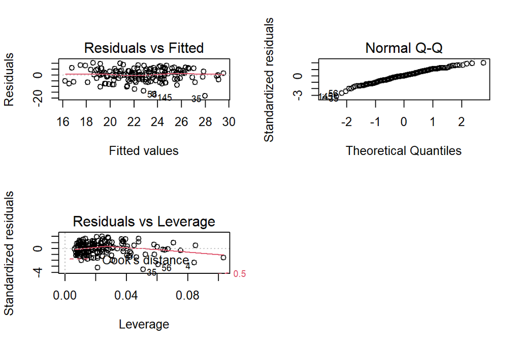

```r
par(mfrow = c(2,2))
plot(my_model, which = c(1, 2, 5))
```

In the Residuals vs. Fitted graph the variance of the residuals is reasonably constant, implying that the size of the errors should not depend on the explanatory variables. The Normal Q-Q plot confirms the assumption that the errors of the model are normally distributed. By observing the residuals vs. leverage plot, no single observation stands out, and the leverage seems regular.

# Week 3: Logistic regression

```
## [1] "Sun Dec 12 17:30:34 2021"
```

This week I’m analysing a joined dataset that includes two student alcohol consumption data sets. Data set information can be found here: https://archive.ics.uci.edu/ml/datasets/Student+Performance The following adjustments have been made: The variables not used for joining the two data have been combined by averaging (including the grade variables)

- ‘alc_use’ is the average of ‘Dalc’ (weekday alcohol usage) and ‘Walc’ (weekend alcohol usage).
- ‘high_use’ is TRUE if ‘alc_use’ is higher than 2 and FALSE otherwise.

The purpose of my analysis is to study the relationships between high/low alcohol consumption and some of the other variables in the data.

## What’s in the dataframe

```r
alc <- read.csv("C:/Users/35840/OneDrive - University of Helsinki/IODS/IODS-project/data/alc.csv")
str(alc)
```

```
## 'data.frame':    370 obs. of  35 variables:
##  $ school    : chr  "GP" "GP" "GP" "GP" ...
##  $ sex       : chr  "F" "F" "F" "F" ...
##  $ age       : int  15 15 15 15 15 15 15 15 15 15 ...
##  $ address   : chr  "R" "R" "R" "R" ...
##  $ famsize   : chr  "GT3" "GT3" "GT3" "GT3" ...
##  $ Pstatus   : chr  "T" "T" "T" "T" ...
##  $ Medu      : int  1 1 2 2 3 3 3 2 3 3 ...
##  $ Fedu      : int  1 1 2 4 3 4 4 2 1 3 ...
##  $ Mjob      : chr  "at_home" "other" "at_home" "services" ...
##  $ Fjob      : chr  "other" "other" "other" "health" ...
##  $ reason    : chr  "home" "reputation" "reputation" "course" ...
##  $ guardian  : chr  "mother" "mother" "mother" "mother" ...
##  $ traveltime: int  2 1 1 1 2 1 2 2 2 1 ...
##  $ studytime : int  4 2 1 3 3 3 3 2 4 4 ...
```

[output cut: 21 more lines]

```r
colnames(alc)
```

```
##  [1] "school"     "sex"        "age"        "address"    "famsize"
##  [6] "Pstatus"    "Medu"       "Fedu"       "Mjob"       "Fjob"
## [11] "reason"     "guardian"   "traveltime" "studytime"  "schoolsup"
## [16] "famsup"     "activities" "nursery"    "higher"     "internet"
## [21] "romantic"   "famrel"     "freetime"   "goout"      "Dalc"
## [26] "Walc"       "health"     "failures"   "paid"       "absences"
## [31] "G1"         "G2"         "G3"         "alc_use"    "high_use"
```

```r
dim(alc)
```

```
## [1] 370  35
```

There are 370 observations over 35 variables. Respondents are studens whose age range from 15 to 22 years, and there are numeric, nominal and binary variables. Binary variables include questions such as students’ sex (F for female, M for male), the school they are from (school), family size (famsize).

## Looking more closely at 4 variables in relation to alcohol consumption:

I believe that it will be interesting to further study these 4 specific variables and how they relate to alcohol consumption.

Here is an overview of the four variables in the dataset:

```r
alc %>% group_by(school, famsize, age, absences) %>% summarise(count = n())
```

```
## # A tibble: 139 x 5
## # Groups:   school, famsize, age [17]
##    school famsize   age absences count
##    <chr>  <chr>   <int>    <int> <int>
##  1 GP     GT3        15        0    13
##  2 GP     GT3        15        1    11
##  3 GP     GT3        15        2    11
##  4 GP     GT3        15        3     9
##  5 GP     GT3        15        4     4
##  6 GP     GT3        15        5     4
##  7 GP     GT3        15        6     4
##  8 GP     GT3        15        7     1
##  9 GP     GT3        15        8     1
## 10 GP     GT3        15       10     1
## # ... with 129 more rows
```

The relationships of variables to alcohol consumption by sex

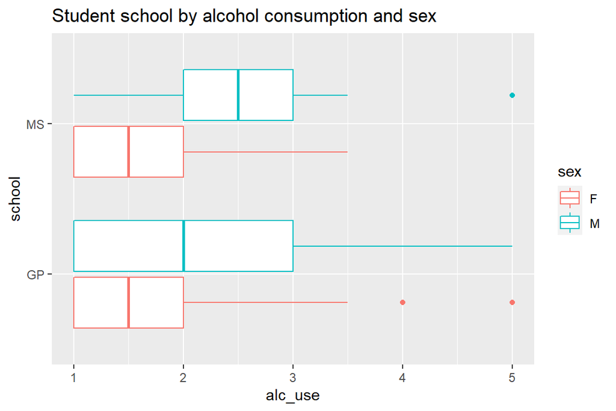

```r
# initialize a plot of alc_use and each variable
g1 <- ggplot(alc, aes(x = alc_use, y = school, col = sex))
g2 <- ggplot(alc, aes(x = alc_use, y = famsize, col = sex))
g3 <- ggplot(alc, aes(x = alc_use, y = age, col = sex))
g4 <- ggplot(alc, aes(x = alc_use, y = absences, col = sex))

# define the plot as a boxplot and draw it
g1 + geom_boxplot() + ylab("school") + ggtitle("Student school by alcohol consumption and sex")
```

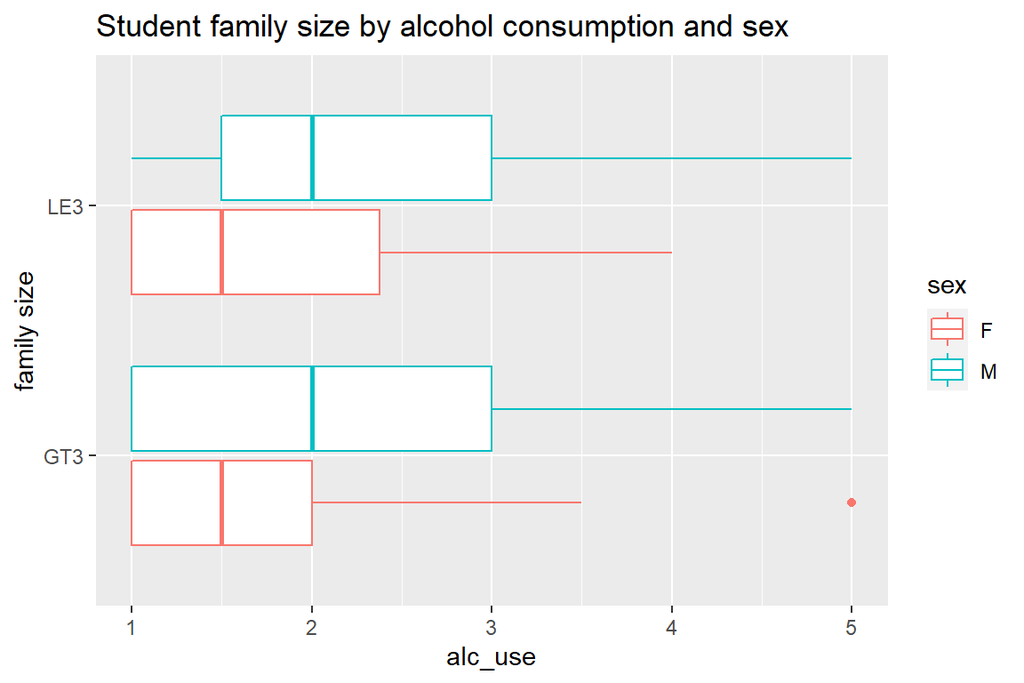

```r
g2 + geom_boxplot() + ylab("family size") + ggtitle("Student family size by alcohol consumption and sex")
```

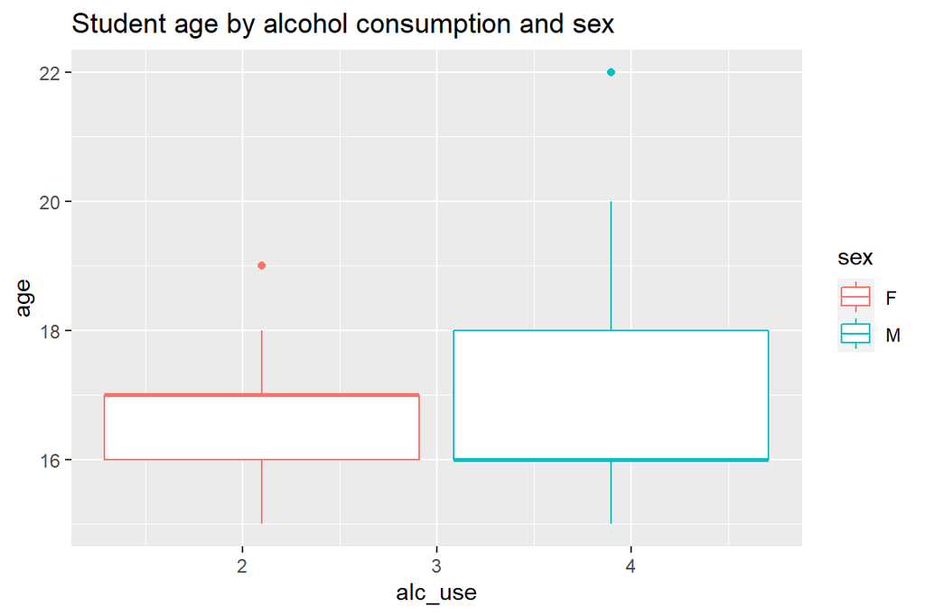

```r
g3 + geom_boxplot() + ylab("age") + ggtitle("Student age by alcohol consumption and sex")
```

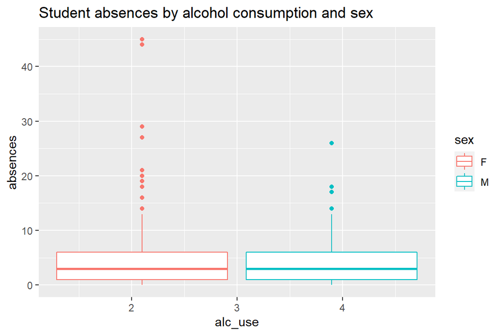

```r
g4 + geom_boxplot() + ylab("absences") + ggtitle("Student absences by alcohol consumption and sex")
```

## Logistic regression analysis

```r
m <- glm(high_use ~ school + famsize + age + absences, data = alc, family = "binomial")
summary(m)
```

```
##
## Call:
## glm(formula = high_use ~ school + famsize + age + absences, family = "binomial",
##     data = alc)
##
## Deviance Residuals:
##     Min       1Q   Median       3Q      Max
## -2.3456  -0.8362  -0.7079   1.2156   1.8873
##
## Coefficients:
##             Estimate Std. Error z value Pr(>|z|)
## (Intercept) -3.47990    1.76472  -1.972 0.048619 *
## schoolMS     0.27129    0.38831   0.699 0.484780
## famsizeLE3   0.34029    0.25365   1.342 0.179731
## age          0.12556    0.10717   1.172 0.241386
## absences     0.08677    0.02357   3.682 0.000232 ***
## ---
## Signif. codes:  0 '***' 0.001 '**' 0.01 '*' 0.05 '.' 0.1 ' ' 1
##
## (Dispersion parameter for binomial family taken to be 1)
##
##     Null deviance: 452.04  on 369  degrees of freedom
## Residual deviance: 429.89  on 365  degrees of freedom
## AIC: 439.89
##
## Number of Fisher Scoring iterations: 4
```

```r
coef(m)
```

```
## (Intercept)    schoolMS  famsizeLE3         age    absences
## -3.47989509  0.27128537  0.34028984  0.12555822  0.08677493
```

```r
# compute odds ratios (OR)
OR <- coef(m) %>% exp

# compute confidence intervals (CI)
CI <- confint(m) %>% exp
# print out the odds ratios with their confidence intervals
cbind(OR, CI)
```

```
##                     OR        2.5 %   97.5 %
## (Intercept) 0.03081064 0.0009345837 0.967702
## schoolMS    1.31164932 0.6019651253 2.783585
## famsizeLE3  1.40535486 0.8505380089 2.303995
## age         1.13378118 0.9186681551 1.400508
## absences    1.09065118 1.0435792600 1.144672
```

For one unit increase in absences, the odds of high alcohol usage increase by a factor of 1,09.There appears a statistically significant correlation between absences and high alcohol usage. Interestingly, all of school=MS, family size = less than 3, and age include 1 within the 95 % confidence interval, which implies that the result is not statistically significant. This result rejects my personal hypothesis as the data does not show obvious connections between the chosen variables and high alcohol usage.

## Predictive power of the model

The only variable with a statistically significant connection to high alcohol usage is “absences”. I’ll explore its prediction capabilities next. Let’s look at the cross tabulation of the prediction versus actual values of high usage:

```r
# fit the model
m2 <- glm(high_use ~ absences, data = alc, family = "binomial")

# predict() the probability of high_use
probabilities <- predict(m2, type = "response")

# add the predicted probabilities to 'alc'
alc <- mutate(alc, probability = probabilities)

# use the probabilities to make a prediction of high_use
alc <- mutate(alc, prediction = (probability > 0.5))

# see the last ten original classes, predicted probabilities, and class predictions
select(alc, absences, high_use, probability, prediction) %>% tail(10)
```

```
##     absences high_use probability prediction
## 361        7     TRUE   0.3432623      FALSE
## 362        3     TRUE   0.2682636      FALSE
## 363        2     TRUE   0.2512202      FALSE
## 364        4     TRUE   0.2860216      FALSE
## 365        3    FALSE   0.2682636      FALSE
## 366        4     TRUE   0.2860216      FALSE
## 367        0    FALSE   0.2193522      FALSE
## 368        4     TRUE   0.2860216      FALSE
## 369        8     TRUE   0.3635185      FALSE
## 370        0    FALSE   0.2193522      FALSE
```

```r
# tabulate the target variable versus the predictions
table(high_use = alc$high_use, prediction = alc$prediction)
```

```
##         prediction
## high_use FALSE TRUE
##    FALSE   254    5
##    TRUE    102    9
```

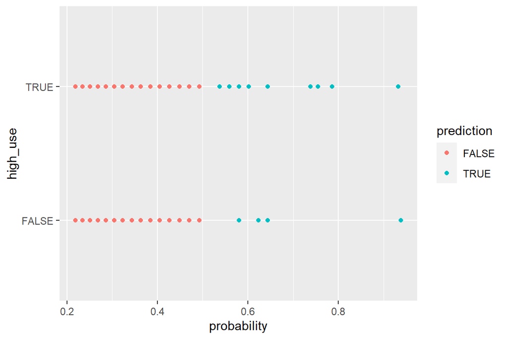

```r
# initialize a plot of 'high_use' versus 'probability' in 'alc'
g <- ggplot(alc, aes(x = probability, y = high_use, col = prediction))

# define the geom as points and draw the plot
g + geom_point()
```

```r
# tabulate the target variable versus the predictions
table(high_use = alc$high_use, prediction = alc$prediction) %>% prop.table %>% addmargins
```

```
##         prediction
## high_use      FALSE       TRUE        Sum
##    FALSE 0.68648649 0.01351351 0.70000000
##    TRUE  0.27567568 0.02432432 0.30000000
##    Sum   0.96216216 0.03783784 1.00000000
```

## Prediction error comparison

```r
# define a loss function (average prediction error)
loss_func <- function(class, prob) {
  n_wrong <- abs(class - prob) > 0.5
  mean(n_wrong)
}

# compute the average number of wrong predictions in the (training) data
loss_func(class = alc$high_use, prob = alc$probability)
```

```
## [1] 0.2891892
```

```r
# K-fold (10-fold) cross-validation
cv <- cv.glm(data = alc, cost = loss_func, glmfit = m, K = 10)

# average number of wrong predictions in the cross validation
cv$delta[1]
```

```
## [1] 0.2837838
```